# Analysis of sensory words, metaphors and comparisons

Bodo

16/11/2020

# 1 Introduction

This analysis will focus on the sensory words and links with Lynott & Connell (2009). It will also look at comparisons and other categorical variables that stem from hand annotation.

# 2 Setup

Load packages:

```r
library(tidyverse)
library(tidytext) # for unnest_tokens()
library(tm) # for Corpus()
library(topicmodels) # for topic models
library(SnowballC) # for stemming words, wordStem()
library(textstem) # for lemmatize_string()
library(brms) # for Bayesian models
library(ldatuning) # for LDA tuning / coherence scores
library(textmineR) # for LDA tuning / coherence scores
library(effsize) # for Cohen's d
```

Get all file names:

```r
birds <- read_csv('../data/birds_master_file_annotated_12_02_25.csv')
```

Load Lynott & Connell (2009):

```r
lyn <- read_csv('../data/lynott_norms.csv')
```

# 3 Temporary limited rows

We’ll limit things to the first 1000 rows:

```r
birds <- slice_head(birds,
                    n = 1000)
```

# 4 Preprocessing

## 4.1 Lynott & Connell (2009) clean-ups

Clean the Lynott & Connell (2009) dataset:

```r
lyn <- lyn |>
  rename(vis = VisualStrengthMean,
         hap = HapticStrengthMean,
         aud = AuditoryStrengthMean,
         olf = OlfactoryStrengthMean,
         gus = GustatoryStrengthMean,
         excl = ModalityExclusivity,
         dom_mod = DominantModality) |>
  select(-(VisualStrengthSD:GustatoryStrengthSD)) |>
  select(-`Item#`,
         -Familiarity,
         -BNCFrequency) |>
  rename(word = Property) |>
  select(-(BNCLogFrequency:OrthographicLength)) |>
  mutate(dom_mod = str_to_lower(dom_mod))
```

## 4.2 Count Warblish & Onomatopoeias

Count Warblish and Onomatopoeias:

```r
birds <- mutate(birds,
                onom_count = str_count(voice_reduced, '\\".+?\\"'),
                warblish_count = str_count(voice_reduced, '\\*.+?\\*'))
```

Check:

```r
birds |> select(voice_reduced, onom_count:warblish_count)
```

```
## # A tibble: 1,000 × 3
##    voice_reduced                                       onom_count warblish_count
##    <chr>                                                    <int>          <int>
##  1 "extraordinary cranking; and honking calls; and wh…          0              0
##  2 "a rapid, soft twittering, given in loud, excited …          0              0
##  3 "a rather sweet \"hooweet\"; a loud warble ending …          1              0
##  4 "quack; a dry, chattering or rattling \"gredek gre…          1              0
##  5 "a harsh and distinctive \"krrarnk\""                        1              0
##  6 "a harsh and repeated \"tchak\""                             1              0
##  7 "a characteristic \"quock\""                                 1              0
##  8 "sounds like \"tseep-eep\""                                  1              0
##  9 "lower-pitched"                                              0              0
## 10 "Low, grunting \"huh-huh-huh-huh\" without change …          2              0
## # ℹ 990 more rows
```

## 4.3 Count comparisons

Create a comparisons count variable, using the `;` as a separator… this one is used when there’s more than one expression, separating each comparison expression.

So counting that, if it’s zero, it means there was a character string - there is a comparison expression - and if there is 1 `;`, that means there’s two comparison expressions:

```r
birds <- mutate(birds,
                comparison_count = str_count(comparison_expression, ';'),
                comparison_count = comparison_count + 1,
                comparison_count = if_else(is.na(comparison_count), 0, comparison_count)) # NAs are zeros
```

But then we need to set to NA those that are not usable, because we’ve taken those with us as unfair zeroes against comparisons in the above:

```r
birds <- mutate(birds,
                comparison_count = if_else(usable != 'yes', NA, comparison_count))
```

In addition, there are those comparison counts that have `NA` but should have a 1 because they are `comparison_only`, and likewise, fairly, for onomatopoeias, there should be a `0` if it’s `comparison_only` (it is an interesting question though whether the expression linked backed to would contain onomatopoeia):

```r
birds <- mutate(birds,
                comparison_count = if_else(usable == 'comparison_only', 1, comparison_count),
                onom_count = if_else(usable == 'comparison_only', 0, onom_count),
                warblish_count = if_else(usable == 'comparison_only', 0, warblish_count))
```

## 4.4 Create cleaned comparison table object

Extract only those expressions that contain comparisons:

```r
comp_only <- filter(birds,
                    complete.cases(comparison_expression)) |>
  select(-length, -warblish, -(non_vocalization:mimicry),
         -(comments:comparison_count))
```

**Note**: The nextcode chunk is only needed when a new bout of data processing comes in to check for consistency of annotations.

Count all semicolons to make sure that expressions are matched:

```r
# comp_counts <- mutate(birds,
#                       type_count = str_count(comparison_type, ';'),
#                       expr_count = str_count(comparison_expression, ';'),
#                       comparand_count = str_count(comparand, ';'),
#                       dim_count = str_count(comp_dimension, ';')) |>
#   select(unique_id, type_count:dim_count) |>
#   filter(!is.na(type_count)) |>
#   filter(comparand_count != expr_count)
#
# # Check these:
#
# comp_counts
```

Looks good (can use above `!=` expression when new data is in).

Now we need to split up the multiple entries. What we’ll do is loop through all rows and if we stumble across a `';'`, we’ll split strings and put them into a new table.

```r
# Setup empty results data frame:

comp_long <- c()

# Loop through rows of comp_only:

for (i in 1:nrow(comp_only)) {
  this_row <- comp_only[i, ]

  # If multi-valued cell, make copies of rows and split, else just append row:

  if (str_detect(this_row$comparison_type, ';')) {
    # How many copies are needed?

    n_copies <- str_count(this_row$comparison_type, ';') + 1 # always one more since ; is separator

    # Temporary data frame:

    temp_df <- c()
    for (i in 1:n_copies) {
      temp_df <- bind_rows(temp_df, this_row)
    }

    # Split relevant columns that need to be split:

    temp_df$comparison_type <- unlist(str_split(this_row$comparison_type, ';'))
    temp_df$comparison_expression <- unlist(str_split(this_row$comparison_expression, ';'))
    temp_df$comp_construction <- unlist(str_split(this_row$comp_construction, ';'))
    temp_df$comparand <- unlist(str_split(this_row$comparand, ';'))
    temp_df$comp_dimension <- unlist(str_split(this_row$comp_dimension, ';'))

    # Append to main tibble:

    comp_long <- bind_rows(comp_long, temp_df)

  } else {
    comp_long <- bind_rows(comp_long, this_row)
  }
}
```

## 4.5 Clean text of onomatopoeias and warblish

Get rid of Warblish and Onomatopoeias:

```r
birds <- mutate(birds,
                voice_reduced = str_replace_all(voice_reduced, '\\".+?\\"', ''),
                voice_reduced = str_replace_all(voice_reduced, '\\*.+?\\*', ''))
```

## 4.6 Other text processing

Make the `voice_reduced` column lowercase:

```r
birds <- mutate(birds,
                voice_reduced = str_to_lower(voice_reduced))
```

Make “far carrying” and “high pitched” and “low pitched” into words so they stick together:

```r
birds <- mutate(birds,
                voice_reduced = str_replace_all(voice_reduced,
                                                "far carrying", "far-carrying"),
                voice_reduced = str_replace_all(voice_reduced,
                                                "high pitched", "high-pitched"),
                voice_reduced = str_replace_all(voice_reduced,
                                                "higher pitched", "high-pitched"),
                voice_reduced = str_replace_all(voice_reduced,
                                                "higher-pitched", "high-pitched"),
                voice_reduced = str_replace_all(voice_reduced,
                                                "lower pitched", "low-pitched"),
                voice_reduced = str_replace_all(voice_reduced,
                                                "lower-pitched", "low-pitched"),
                voice_reduced = str_replace_all(voice_reduced,
                                                "low pitched", "low-pitched"),
                voice_reduced = str_replace_all(voice_reduced,
                                                "up-slurred", "upslurred"),
                voice_reduced = str_replace_all(voice_reduced,
                                                "widely spaced", "widely-spaced"))
```

Match spelling of flutey, fluty, and fluting using the first:

```r
birds <- mutate(birds,
                voice_reduced = str_replace_all(voice_reduced,
                                                'fluty', 'flutey'),
                voice_reduced = str_replace_all(voice_reduced,
                                                'fluting', 'flutey'))
```

## 4.7 Exclude unusables

Get rid of unusables (silent, non-vocal-only, and mere statement that there is no record of a call). We’ll leave `comparisons_only` in because otherwise that would be unfair to comparisons - these are comparisons after all.

```r
birds <- filter(birds,
                usable %in% c('yes', 'comparison_only'))
```

## 4.8 Make long format

Unnest tokens in the voice dataset but don’t break up hyphens:

```r
birds_long <- birds |>
  unnest_tokens(word,
                voice_reduced,
                token = 'regex',
                pattern = "['?!;:, \\.\\)\\(\\)\\/]")
```

# 5 Topic analysis

Amend stop words from `tm` package:

```r
my_stop_words <- c(stopwords("en"), c('also', 'like', 'often', 'rather'))
```

Let’s try to run a topic analysis with the current data. First, we need to setup the data with some additional cleaning steps:

```r
birds <- mutate(birds,
                # voice_reduced2 = removePunctuation(voice_reduced),
                voice_reduced2 = removeNumbers(voice_reduced),
                voice_reduced2 = removeWords(voice_reduced, my_stop_words)
                # voice_reduced2 = wordStem(voice_reduced, language = 'en'),
                )
```

Get rid of the words call, note, and song as these come up in almost any description:

```r
birds <- mutate(birds,
                voice_reduced2 = str_replace_all(voice_reduced2,
                                                 'calls|notes|songs|sounds', ''),
                voice_reduced2 = str_replace_all(voice_reduced2,
                                                 'call|note|song|sound', ''))
```

Split it by ‘;’, which is the separator I use for distinct pieces of vocalization descriptions:

```r
chunk_df <- tibble(chunk = unlist(str_split(birds$voice_reduced2, ';')))
```

Create a corpus and term-document-matrix from this:

```r
# Corpus:

corpus <- Corpus(VectorSource(chunk_df$chunk))

# Term-document matrix:

dtm <- DocumentTermMatrix(corpus, control = list(
  stopwords = TRUE,
  removePunctuation = TRUE,
  removeNumbers = TRUE,
  stemming = FALSE
))

# Remove empty rows for LDA:

dtm <- dtm[rowSums(as.matrix(dtm)) > 0, ]
```

Remove sparse terms:

```r
# dtm <- removeSparseTerms(dtm, 0.999)
```

```r
# Convert DTM to required format
# dtm_matrix <- as.matrix(dtm)
#
# # Fit LDA models for different topic numbers
# coherence_scores <- sapply(seq(2, 10, by = 1), function(k) {
#   model <- FitLdaModel(dtm = dtm_matrix, k = k, iterations = 500, burnin = 200, seed = 1234)
#   CalcProbCoherence(model$phi, dtm_matrix, M = 5)  # Get coherence score
# })
#
# # Plot Coherence Scores
# plot(seq(2, 10, by = 1), coherence_scores, type = "b",
#      xlab = "Number of Topics", ylab = "Coherence Score",
#      main = "Coherence Score vs Number of Topics")
```

Find appropriate number of topics as per coherence score:

```r
# result <- FindTopicsNumber(
#   dtm,
#   topics = seq(2, 10, by = 1),  # Range of k values
#   metrics = "Coherence",
#   method = "Gibbs",
#   control = list(seed = 1234),
#   verbose = TRUE
# )
#
# FindTopicsNumber_plot(result)
```

Run the topic model:

```r
# Set number of topics:

num_topics <- 6  # Adjust as needed

# Run LDA:

lda_model <- LDA(dtm, k = num_topics, control = list(seed = 1234))

# Extract topics:

topics <- tidy(lda_model, matrix = "beta")

# Get top terms per topic:

top_terms <- topics %>%
  group_by(topic) %>%
  slice_max(beta, n = 5) %>%
  ungroup() %>%
  arrange(topic, desc(beta))
```

Show top terms:

```r
top_terms |>
  print(n = Inf)
```

```
## # A tibble: 30 × 3
##    topic term          beta
##    <int> <chr>        <dbl>
##  1     1 rapid       0.0389
##  2     1 loud        0.0343
##  3     1 high        0.0247
##  4     1 long        0.0230
##  5     1 soft        0.0210
##  6     2 loud        0.0698
##  7     2 harsh       0.0614
##  8     2 sharp       0.0377
##  9     2 whistled    0.0275
## 10     2 whistle     0.0248
## 11     3 repeated    0.0353
## 12     3 nasal       0.0307
```

[output cut: 18 more lines]

# 6 Analysis of distinctive words

What are the most frequent words?

```r
# Count word tokens:

word_count <- birds_long |>
  count(word, sort = TRUE) |>
  filter(!word %in% stop_words)

# Show:

word_count |>
  print(n = Inf)
```

```
## # A tibble: 1,044 × 2
##      word                    n
##      <chr>               <int>
##    1 "a"                   962
##    2 "and"                 357
##    3 "of"                  215
##    4 "or"                  214
##    5 "notes"               211
##    6 "call"                185
##    7 "loud"                178
##    8 "with"                142
##    9 "sharp"               141
##   10 "song"                140
##   11 "series"              135
##   12 "high"                123
```

[output cut: 1032 more lines]

Get rid of stop words and numbers:

**Note**: I’m using `'one-'` here to avoid matches with words like “tone” or “lonely”.

```r
# Number words:

number_words <- c('one-', 'two', 'three',
                  'four', 'five', 'six',
                  'seven', 'eight', 'nine',
                  '^ten',
                  '^one',
                  'triple', 'double', 'single',
                  'bisyllabic', 'monosyllabic',
                  'disyllabic',
                  'trisyllabic', 'couple',
                  'minutes', 'seconds', 'sec',
                  'minute', 'second',
                  'many-syllabled', 'dozen',
                  'singly')

# Exclude number words:

birds_long <- filter(birds_long,
                     !str_detect(word, str_c(number_words, collapse = '|'))) |>
  filter(!str_detect(word, '[0-9]'))

# Load stop words from tidyverse package:

data(stop_words)

# Get rid of stop words via anti_join():

birds_long <- birds_long |> anti_join(stop_words)
# Count word tokens again:

word_count <- birds_long |>
  count(word, sort = TRUE) |>
  filter(!word %in% stop_words)

# Show:

word_count |>
  print(n = Inf)
```

```
## # A tibble: 788 × 2
##     word                    n
##     <chr>               <int>
##   1 "notes"               211
##   2 "call"                185
##   3 "loud"                178
##   4 "sharp"               141
##   5 "song"                140
##   6 "series"              135
##   7 "harsh"               120
##   8 "calls"               107
##   9 "high-pitched"         99
##  10 "rapid"                99
##  11 "soft"                 96
##  12 "low"                  84
```

[output cut: 776 more lines]

Get rid of the `-sounding` bits, e.g., “weak-sounding” and “wooden-sounding” can just be “weak” and “wooden”:

```r
birds_long <- mutate(birds_long,
                     word = str_replace_all(word, '-sounding', ''))
```

Lemmatize the long list:

```r
birds_long_red <- mutate(birds_long,
                         word == lemmatize_strings(word))
```

Show again:

```r
# Count word tokens again:

word_count <- birds_long_red |>
  count(word, sort = TRUE) |>
  filter(!word %in% stop_words)

# Show again:

word_count |>
  print(n = Inf)
```

```
## # A tibble: 782 × 2
##     word                    n
##     <chr>               <int>
##   1 "notes"               211
##   2 "call"                185
##   3 "loud"                178
##   4 "sharp"               141
##   5 "song"                140
##   6 "series"              135
##   7 "harsh"               120
##   8 "calls"               107
##   9 "high-pitched"         99
##  10 "rapid"                99
##  11 "soft"                 96
##  12 "low"                  84
```

[output cut: 770 more lines]

Get rid of other words, which includes language about the sequencing, also nouns that are about variation, as well as nouns and verbs more generally, as well as words that are just degree words (mostly adverbs) and words about the author’s perception, such as *remarkable* or *surprising*.

```r
my_stops <- c('emit', 'emits',
              'elements', 'increases',
              'finish', 'eventually',
              'consists', 'combine',
              'adds', 'tone',
              'strongly', 'vary', 'volume',
              'set', 'sequences', 'fairly',
              'giving', 'bit', 'starts',
              'consisting', 'delivered',
              'lasts', 'extremely', 'version',
              'typically', 'include',
              'start', 'begin', 'run',
              'sounding', 'periods',
              'passages', 'pauses', 'noted',
              'builds', 'additional', 'change',
              'strung', 'together', 'gradually',
              'form', 'building', 'averages',
              'averaging', 'variation',
              'including', 'combined',
              'alternating', 'succession',
              'trending', 'trend',
              'theme', 'temp', 'tend',
              'terminal', 'taper',
              'suddenly', 'successions',
              'successively', 'straight',
              'shortened', 'shortening',
              'separated', 'sets', 'selection',
              'replaced', 'repertoire', 'returns',
              'reiterated', 'quickly',
              'question', 'answer', 'moving',
              'momentum', 'moment', 'moments',
              'leading', 'inserted', 'initial',
              'final', 'incorporates',
              'word', 'waterdrop', 'wave',
              'voices', 'vocalizations', 'uttering',
              'well-spaced', 'versions', 'unusually',
              'repetitions', 'repeats', 'pair', 'pairs',
              'multiple', 'switch', 'string', 'silence',
              'progress', 'passage', 'middle', 'mix',
              'forever', 'effect', 'waterdrop',
              'diminishing', 'die', 'details',
              'definite', 'definitive', 'contrasting',
              'continues', 'consist',
              'concludes', 'composed',
              'combines', 'combination', 'close',
              'chant', 'calling', 'broken', 'bout',
              'background', 'average', 'alternate',
              'alternative', 'accompanied',
              'singing', 'pitches', 'length',
              'inflection', 'immediately',
              'regular', 'remarkable',
              'speed', 'scold', 'preceded', 'preceding',
              'mixture', 'introductory', 'initially',
              'primary', 'tempo', 'intermixed',
              'intermingle', 'intermingled',
              'duet', 'intervals', 'interspersed',
              'voice', 'variety', 'variations',
              'times', 'sing', 'phrases', 'sounds',
              'note', 'series', 'calls', 'call',
              'notes', 'strengths', 'stream',
              'kkkkkk\"', # typo
              'irregularly', 'grow', 'gaps',
              'forming', 'foundation', 'fragments',
              'finally', 'extraordinary',
              'excitement', 'emphasized', 'emphasizing',
              'dying', 'duets', 'divided',
              'conglomeration', 'concluding',
              'climax', 'climaxes',
              'cadence', 'burst', 'build',
              'accent', 'structure', 'scale',
              'accelerates', 'pause', 'includes',
              'left', # in left-out
              'noisy', # excluded because it often just refers to them being noisy, i.e., vocal
              'beginning', 'lasting',
              'growls', 'croaks')

# More nouns:

more_nouns <- c('flourish', 'duration', 'emphasis', 'cascade',
                'noises', 'chorus', 'syllable', 'noise',
                'bursts', 'songs', 'phrase', 'quality',
                'sound', 'tune', 'torrent', 'forms',
                'types', 'range', 'intensity', 'syllables',
                'pattern', 'refrain', 'medley', 'pace', 'rhythm',
                'flurry', # used as a noun
                'song', 'loudness',
                'confusion', 'cacophony',
                'melody', 'scoldings',
                'exhalation', 'horn',
                'repetition', 'spiral',
                'reel', 'mellowness',
                'trill', 'knocks', 'trills',
                'pitch', 'outpouring',
                'crescendo', 'sequence')

# More verbs:

more_verbs <- c('scolds', 'varies', 'begins', 'moves',
                'finishing', 'tapers', 'spaced', 'produces',
                'pitched', 'changing', 'increasing', 'decreasing',
                'truncating', 'sweeps', 'strengthen',
                'strengthening', 'rolls', 'accelerate',
                'slowing', 'repeat', 'comprises',
                'drumming', # exclude for non because probably non-vocal
                'drawn')

# More adverbs:

more_adverbs <- c('slight')

# Exclude these:

birds_long_red <- filter(birds_long_red,
                         !(word %in% my_stops)) |>
  filter(!(word %in% more_nouns)) |>
  filter(!(word %in% more_verbs)) |>
  filter(!(word %in% more_adverbs))

# Count word tokens again:

word_count <- birds_long_red |>
  count(word, sort = TRUE) |>
  filter(!word %in% stop_words) |>
  filter(!is.na(word)) # get rid of NAs

# Show again:

word_count |>
  print(n = Inf)
```

```
## # A tibble: 521 × 2
##     word                  n
##     <chr>             <int>
##   1 loud                178
##   2 sharp               141
##   3 harsh               120
##   4 high-pitched         99
##   5 rapid                99
##   6 soft                 96
##   7 low                  84
##   8 repeated             82
##   9 nasal                72
##  10 short                69
##  11 rising               63
##  12 musical              62
```

[output cut: 509 more lines]

Classify some of these words - for questionable cases regarding onomatopoeia, e.g., *wail*, I used the iconicity ratings as guide:

```r
onomatopoeias <- c('zing', 'yelps', 'yelping', 'yelp',
                   'whoops', 'whooping', 'whirrs',
                   'warbly', 'warbled', 'warblings',
                   'wails', 'twitterlings',
                   'twittered',
                   'toots', 'squeaking', 'squeak',
                   'squawking', 'squawkings', 'spinking',
                   'shrieked', 'screechy',
                   'purrs', 'peep', 'kip',
                   'hum', 'howls', 'howling',
                   'gulping', 'gurgles', 'growled',
                   'growl', 'gobble', 'fizzing',
                   'crow', 'croakings',
                   'clanking', 'clacking',
                   'churrings', 'chucks',
                   'chortle', 'chitter',
                   'chirrups', 'chirrup',
                   'chirp', 'chipping', 'chippering',
                   'chattered', 'cawing', 'cacklings',
                   'burr', 'burbling', 'bleating',
                   'baying', 'barked', 'squeakier',
                   'squeak', 'squawk', 'shrieks',
                   'shriek', 'purr', 'mew', 'jingle',
                   'chatterings', 'chittering',
                   'buzzes', 'wheeze',
                   'sputtering', 'rattles',
                   'jingling', 'jangling',
                   'hoot', 'hisses', 'honks',
                   'gargling', 'groans',
                   'wheeze', 'whine',
                   'ticking',
                   'clicks', 'chirps',
                   'cackles', 'stuttering',
                   'shrieking', 'screeching',
                   'quacking', 'gruff',
                   'hoots', 'creaking', 'coos',
                   'chuckling', 'cackle',
                   'wailing', 'squealing',
                   'quack', 'hiss', 'grunt',
                   'crowing', 'cluck', 'chirping',
                   'booming', 'barks',
                   'bark',
                   'wheezy',
                   'warbles', 'squawks',
                   'squeal', 'screech',
                   'purring', 'hooting',
                   'clucks', 'twitters',
                   'squeaks', 'croacks',
                   'clucking', 'honking',
                   'quacks', 'gurgling',
                   'grunts', 'cackling',
                   'twitter', 'growling',
                   'barking', 'chips',
                   'cooing', 'churring',
                   'tinkling', 'croaking',
                   'warbling', 'buzz',
                   'buzzing', 'chip',
                   'hissing', 'chatter', 'chattering',
                   'rattle', 'twittering',
                   'shrill',
                   'snoring', 'sneezy', 'sneezing',
                   'snarls', 'sighs', 'moan', 'moans',
                   'jangle', 'grunt-like',
                   'cranking', # cranky is above 5 in iconicity ratings
                   'cracking', 'cough', 'coughing',
                   'buzzier', 'burp', 'yodel',
                   'yapping', 'squeals',
                   'peeping', 'moaning', 'murmuring',
                   'yodelling', 'clicking',
                   'screeches',
                   'screaming', # more than 5, so I'll do the other ones as well:
                   'scream', 'screams',
                   'warble', 'squeaky',
                   'buzzy', 'rattling',
                   'whiny', 'whinny', 'whines',
                   'hiccup', 'grunty',
                   'chukled', 'whisper',
                   'wheezing', 'rippling',
                   'mewing', 'squeaked',
                   'whistling', # has more than 5
                   'ringing', # ring has more than 5
                   'creaky', 'chuckled',
                   'whining', # base word more than 5
                   'croak', 'grunting',
                   'whistles', 'whistle', 'whistled', # whistling has more than 5
                   'rambling', # ramble above 5
                   'rattled',
                   'mumbled',
                   'hiss-like',
                   'stuttered')

# Spatial metaphors:

spatial_pitch <- c('ascending', 'descending',
                   'descend',
                   'ascends', 'descends',
                   'high-pitched', 'upward',
                   'downward', 'lowest', 'low-high-low',
                   'dropping', 'downward-slurring',
                   'rise', 'upslurred',
                   'rises', 'low-pitched',
                   'rising', 'low', 'high-pitched',
                   'upslur', 'lowering',
                   'lifts', 'lifting', 'fall',
                   'lisping', # higher than 6
                   'lower',
                   'falls', 'falling',
                   'uplift')

# Human voice descriptor:

human_voice <- c('nasal', 'ventriloquial', 'throaty', 'chestier',
                 'choking', 'laughing', 'guttural', 'strangled',
                 'inhaled', 'talky', 'cries', 'cry',
                 'slurred', 'spitting')

# Emotional descriptors:

emotional <- c('warning', 'urgent', 'wistful', 'sad', 'manic',
               'lazy', 'lazier', 'exuberant', 'excitedly',
               'aggressive', 'deliberate', 'anxious',
               'angry', 'lively', 'cheery', 'cheerful',
               'mournful', 'excited',
               'sorrowful', 'complaining',
               'scolding', 'incisive', 'gentle',
               'subdued', 'peevish',
               'agitated', 'deliberately',
               'relaxed', 'lonely',
               'tirelessly',
               'rollicking',
               'querulous',
               'quavering',
               'confused', 'insistent',
               'desolately')

# Gustatory words:

gustatory <- c('sweet', 'sweeter', 'sweetest')

# Evaluative descriptors:

evaluatives <- c('unpleasant', 'beautifully', 'weird',
                 'beautiful', 'pleasant', 'strange',
                 'chilling', # a bit contentious?
                 'spirited', 'delightful',
                 'comical')

# Visual descriptors:

visuals <- c('bright', 'silvery', 'clear', 'clearer',
             'clearest')

# Taste:

taste <- c('sweet', 'sweeter')

# Other spatial words:

spatial_other <- c('tiny', 'deep', 'hollow',
                   'thinner', 'deeper',
                   'thin', 'thick', 'thinner', 'thicker',
                   'flat', 'uneven',
                   'even-pitched', 'broad',
                   'fuller', 'full',
                   'level')

# Complexity and variation words:

complexity <- c('simple', 'complex', 'complicated',
                'flexible', 'varied', 'rudimentary',
                'varying', 'simpler', 'variable',
                'simpler', 'undefined')

# Distinctive / recognizability type words:

distinctive <- c('distinctive', 'familiar',
                 'characteristic', 'undistinctive',
                 'unmistakable', 'distinct',
                 'diagnostic', 'unique')

# Haptic word:

haptics <- c('sharp', 'soft',
             'rough', 'smooth',
             'wiry', 'tearing',
             'smoother', 'gravelly',
             'rougher', 'brassy',
             'sharply', 'drier',
             'wooden', 'softly',
             'harder', 'metallic',
             'mechanical', 'sharper',
             'softer', 'hard', 'dry',
             'sharp', 'solid',
             'rusty', 'crisp',
             'scratchy',
             'coarse', 'coarser',
             'bumpy')

# Water-related:

water <- c('fluid', 'liquid', 'flowing',
           'free-flowing', 'bubbly',
           'bubbling') # bubbly is a bit contentious

# Length adjectives:

length <- c('short', 'lengthy', 'extended',
            'shorter', 'short-spaced',
            'protracted', 'widely-spaced',
            'prolonged', 'drawn-out',
            'long-drawn')

# Loudness / amplitude / intensity:

amplitude <- c('loud', 'crescendoing',
               'deafening', 'audible',
               'loudest', 'loudly',
               'faint', # arguably multisensory
               'inaudible', 'louder',
               'quieter', 'quiet',
               'muted')

# Strength words:

strength <- c('strong', 'stronger', 'strongest',
              'weaker', 'weak',
              'powerful')

# Speed terms:

speed <- c('rapid', 'fast', 'speeded-up',
           'fast-repeated', 'deccelerating',
           'accelerating', 'quicker',
           'quick', 'faster', 'slow-paced',
           'hurried', # correct?
           'slower', 'slow', 'slowly')

# Repetition and rhythm:

rhythm_repetition <- c('repetitive', 'repeated', 'rhythmic',
                       'repeated', 'staccato', 'much-repeated',
                       'repetitious')

# Musicality or melody:

musical <- c('unmelodious', 'melodious',
             'musical', 'tuneful', 'melodic',
             'non-musical', 'unmusical')

# Movement word:

movement_word <- c('bouncing', 'bouncy', 'rolled',
                   'tumbling')

# Prominence-related:

prominence <- c('accented', 'emphatic', 'pronounced',
                'prominent')

# Continuity & pitch development:

continuity <- c('continuous', 'constant',
                'continuously', 'monotonous',
                'undulating', 'lilting',
                'fixed', 'steady',
                'unbroken', # arguably also touch
                'monotonously')

# Match onomatopoeias:

word_count <- mutate(word_count,
                     word_type = NA,
                     word_type = if_else(word %in% onomatopoeias, 'onomatopoeia', word_type),
                     word_type = if_else(word %in% spatial_pitch, 'spatial_pitch', word_type),
                     word_type = if_else(word %in% human_voice, 'human_voice', word_type),
                     word_type = if_else(word %in% haptics, 'haptic', word_type),
                     word_type = if_else(word %in% spatial_other, 'other_spatial', word_type),
                     word_type = if_else(word %in% visuals, 'visual', word_type),
                     word_type = if_else(word %in% prominence, 'prominence_word', word_type),
                     word_type = if_else(word %in% water, 'water_related_word', word_type),
                     word_type = if_else(word %in% evaluatives, 'evaluative', word_type),
                     word_type = if_else(word %in% emotional, 'emotional', word_type),
                     word_type = if_else(word %in% human_voice, 'human_voice', word_type),
                     word_type = if_else(word %in% amplitude, 'amplitude_word', word_type),
                     word_type = if_else(word %in% complexity, 'song_complexity_word', word_type),
                     word_type = if_else(word %in% strength, 'strength_word', word_type),
                     word_type = if_else(word %in% distinctive, 'distinctive_word', word_type),
                     word_type = if_else(word %in% movement_word, 'movement_word', word_type),
                     word_type = if_else(word %in% length, 'length_word', word_type),
                     word_type = if_else(word %in% taste, 'taste_word', word_type),
                     word_type = if_else(word %in% speed, 'speed_word', word_type),
                     word_type = if_else(word %in% rhythm_repetition, 'rhythm_repetition_word', word_type),
                     word_type = if_else(word %in% musical, 'musical_word', word_type),
                     word_type = if_else(word %in% gustatory, 'taste_word', word_type))

# Show again:

word_count
```

```
## # A tibble: 521 × 3
##    word             n word_type
##    <chr>        <int> <chr>
##  1 loud           178 amplitude_word
##  2 sharp          141 haptic
##  3 harsh          120 <NA>
##  4 high-pitched    99 spatial_pitch
##  5 rapid           99 speed_word
##  6 soft            96 haptic
##  7 low             84 spatial_pitch
##  8 repeated        82 rhythm_repetition_word
##  9 nasal           72 human_voice
## 10 short           69 length_word
## # ℹ 511 more rows
```

Check:

```r
word_count |>
  count(word_type, sort = TRUE) |>
  print(n = Inf)
```

```
## # A tibble: 21 × 2
##    word_type                  n
##    <chr>                  <int>
##  1 onomatopoeia             190
##  2 <NA>                     113
##  3 emotional                 36
##  4 haptic                    27
##  5 spatial_pitch             27
##  6 human_voice               14
##  7 speed_word                14
##  8 amplitude_word            12
##  9 other_spatial             12
## 10 length_word               10
## 11 song_complexity_word      10
## 12 evaluative                 9
## 13 distinctive_word           8
## 14 musical_word               7
## 15 rhythm_repetition_word     6
## 16 strength_word              6
## 17 water_related_word         6
## 18 movement_word              4
## 19 prominence_word            4
## 20 visual                     4
## 21 taste_word                 2
```

**Important note**: In these counts (that will not be reported in the talk), the human voice category is disadvantaged because many of them that are onomatopoeic (*sneezing*, *hiccup* etc.) are counted towards onomatopoeia. That will be fixed below when we look at human voice terms, where I’ll re-merge some of the clearly human-voice related onomatopoeias back into the human voice category.

That is, this way of carving up the word space does not allow for multi-associations. I’ll re-add those onomatopoeias that can also be ascribed to humans in the count of human voice metaphors below.

# 7 Distinctive words back into corpus

## 7.1 Preprocessing

Re-add onomatopoeias that clearly relate to human voice to the `human_voice` vector:

**Note**: Here, I only took the most obviously human-related ones, like snoring, sneezy, and yodeling. Some hard decisions will have to be made about cases like whine, scream, shriek, … need a better measure for human-voice-relatedness. Perhaps distributional semantics?

```r
human_voice <- c(human_voice,
                 c('stuttering', 'stuttered',
                   'snoring', 'sneezy', 'sneezing',
                   'sighs', 'cough', 'coughing',
                   'moan', 'moans', 'burp',
                   'yodel', 'yodelling'))
```

We’ll go through the corpus and see in how many descriptions we find a conventionalized onomatopoeia, an emotional term, a haptic word, a visual word, a spatial_pitch word, an other spatial word, and a taste word.

```r
birds <- mutate(birds,
                vis_metaphor = str_count(voice_reduced, str_c(visuals, collapse = '|')),
                pitch_metaphor = str_count(voice_reduced, str_c(spatial_pitch, collapse = '|')),
                spatial_other = str_count(voice_reduced, str_c(spatial_other, collapse = '|')),
                taste_metaphor = str_count(voice_reduced, str_c(gustatory, collapse = '|')),
                touch_metaphor = str_count(voice_reduced, str_c(haptics, collapse = '|')),
                human_voice = str_count(voice_reduced, str_c(human_voice, collapse = '|')),
                emotion_metaphor = str_count(voice_reduced, str_c(emotional, collapse = '|')),
                conv_onom = str_count(voice_reduced, str_c(onomatopoeias, collapse = '|')))
```

Check these variables:

```r
birds |> select(vis_metaphor:conv_onom)
```

```
## # A tibble: 950 × 8
##    vis_metaphor pitch_metaphor spatial_other taste_metaphor touch_metaphor
##           <int>          <int>         <int>          <int>          <int>
##  1            0              0             0              0              0
##  2            0              0             0              0              2
##  3            0              0             0              1              1
##  4            0              0             0              0              1
##  5            0              0             0              0              0
##  6            0              0             0              0              0
##  7            0              0             0              0              0
##  8            0              0             0              0              0
##  9            0              1             0              0              0
## 10            0              2             0              0              2
## # ℹ 940 more rows
## # ℹ 3 more variables: human_voice <int>, emotion_metaphor <int>,
## #   conv_onom <int>
```

## 7.2 Wild and tame onomatopoeia

Let’s compare wild and tame onomatopoeia:

```r
birds |>
  summarize(tame_onom = sum(conv_onom, na.rm = TRUE),
            wild_onom = sum(onom_count))
```

```
## # A tibble: 1 × 2
##   tame_onom wild_onom
##       <int>     <dbl>
## 1      1034      1382
```

How many have at least one of them?

```r
birds <- mutate(birds,
                has_any_onom = conv_onom + onom_count,
                has_any_onom = if_else(has_any_onom > 0, 'has onomatopoeia', 'no onomatopoeia'))

# Check:

birds |>
  count(has_any_onom) |>
  filter(!is.na(has_any_onom)) |>
  mutate(p = n / sum(n))
```

```
## # A tibble: 2 × 3
##   has_any_onom         n      p
##   <chr>            <int>  <dbl>
## 1 has onomatopoeia   861 0.925
## 2 no onomatopoeia     70 0.0752
```

93% of all entries.

## 7.3 Metaphor counts

How many have haptic metaphors? (“linguistic synesthesia”, or “synesthetic metaphors”)

```r
birds <- mutate(birds,
                has_haptic_metaphor = touch_metaphor,
                has_haptic_metaphor = if_else(has_haptic_metaphor > 0, 'has haptic metaphor', 'no haptic metaphor'))

# Count:

birds |>
  count(has_haptic_metaphor) |>
  filter(!is.na(has_haptic_metaphor)) |>
  mutate(p = n / sum(n))
```

```
## # A tibble: 2 × 3
##   has_haptic_metaphor     n     p
##   <chr>               <int> <dbl>
## 1 has haptic metaphor   317 0.340
## 2 no haptic metaphor    614 0.660
```

How many have spatial metaphors? (“linguistic synesthesia”, or “synesthetic metaphors”)

```r
birds <- mutate(birds,
                has_pitch_metaphor = pitch_metaphor,
                has_pitch_metaphor = if_else(has_pitch_metaphor > 0,
                                             'has spatial pitch metaphor',
                                             'no spatial pitch metaphor'))

# Count:

birds |>
  count(has_pitch_metaphor) |>
  filter(!is.na(has_pitch_metaphor)) |>
  mutate(p = n / sum(n))
```

```
## # A tibble: 2 × 3
##   has_pitch_metaphor             n     p
##   <chr>                      <int> <dbl>
## 1 has spatial pitch metaphor   321 0.345
## 2 no spatial pitch metaphor    610 0.655
```

How many have visual metaphors? (“linguistic synesthesia”, or “synesthetic metaphors”)

```r
birds <- mutate(birds,
                has_visual_metaphor = vis_metaphor,
                has_visual_metaphor = if_else(has_visual_metaphor > 0, 'has visual metaphor', 'no visual metaphor'))

# Count:

birds |>
  count(has_visual_metaphor) |>
  filter(!is.na(has_visual_metaphor)) |>
  mutate(p = n / sum(n))
```

```
## # A tibble: 2 × 3
##   has_visual_metaphor     n      p
##   <chr>               <int>  <dbl>
## 1 has visual metaphor    76 0.0816
## 2 no visual metaphor    855 0.918
```

How many have taste metaphors? (“linguistic synesthesia”, or “synesthetic metaphors”)

```r
birds <- mutate(birds,
                has_taste_metaphor = taste_metaphor,
                has_taste_metaphor = if_else(has_taste_metaphor > 0, 'has taste metaphor', 'no taste metaphor'))

# Count:

birds |>
  count(has_taste_metaphor) |>
  filter(!is.na(has_taste_metaphor)) |>
  mutate(p = n / sum(n))
```

```
## # A tibble: 2 × 3
##   has_taste_metaphor     n      p
##   <chr>              <int>  <dbl>
## 1 has taste metaphor    17 0.0183
## 2 no taste metaphor    914 0.982
```

How many have human voice terms?

```r
birds <- mutate(birds,
                has_voice_metaphor = human_voice,
                has_voice_metaphor = if_else(has_voice_metaphor > 0, 'has human voice metaphor', 'no human voice metaphor'))

# Count:

birds |>
  count(has_voice_metaphor) |>
  filter(!is.na(has_voice_metaphor)) |>
  mutate(p = n / sum(n))
```

```
## # A tibble: 2 × 3
##   has_voice_metaphor           n     p
##   <chr>                    <int> <dbl>
## 1 has human voice metaphor   146 0.157
## 2 no human voice metaphor    785 0.843
```

How many have human emotional terms?

```r
birds <- mutate(birds,
                has_emotion_metaphor = emotion_metaphor,
                has_emotion_metaphor = if_else(has_emotion_metaphor > 0, 'has human emotion metaphor', 'no human emotion metaphor'))

# Count:

birds |>
  count(has_emotion_metaphor) |>
  filter(!is.na(has_emotion_metaphor)) |>
  mutate(p = n / sum(n))
```

```
## # A tibble: 2 × 3
##   has_emotion_metaphor           n      p
##   <chr>                      <int>  <dbl>
## 1 has human emotion metaphor    87 0.0934
## 2 no human emotion metaphor    844 0.907
```

How many have other spatial terms like *deep* and *hollow*?

```r
birds <- mutate(birds,
                has_spatial = spatial_other,
                has_spatial = if_else(has_spatial > 0,
                                      'has other spatial metaphor',
                                      'no other spatial metaphor'))

# Count:

birds |>
  count(has_spatial) |>
  filter(!is.na(has_spatial)) |>
  mutate(p = n / sum(n))
```

```
## # A tibble: 2 × 3
##   has_spatial                    n     p
##   <chr>                      <int> <dbl>
## 1 has other spatial metaphor   109 0.117
## 2 no other spatial metaphor    822 0.883
```

How many have any spatial, so spatial pitch (high/low/etc.) and other spatial (deep/hollow/etc.) combined?

```r
birds <- mutate(birds,
                has_any_spatial = pitch_metaphor + spatial_other,
                has_any_spatial = if_else(has_any_spatial > 0,
                                          'has any spatial',
                                          'no spatial'))

# Count:

birds |>
  count(has_any_spatial) |>
  filter(!is.na(has_any_spatial)) |>
  mutate(p = n / sum(n))
```

```
## # A tibble: 2 × 3
##   has_any_spatial     n     p
##   <chr>           <int> <dbl>
## 1 has any spatial   365 0.392
## 2 no spatial        566 0.608
```

Any of these metaphor counts?

```r
birds <- mutate(birds,
                has_any_metaphor = if_else(has_any_spatial == 'has any spatial'|
                                             has_haptic_metaphor == 'has haptic metaphor' |
                                             has_emotion_metaphor == 'has human emotion metaphor' |
                                             has_taste_metaphor == 'has taste metaphor' |
                                             has_voice_metaphor == 'has human emotion metaphor' |
                                             has_visual_metaphor == 'has visual metaphor',
                        'has metaphor', 'none of these metaphors'))
```

Check count:

```r
birds |>
  count(has_any_metaphor) |>
  filter(!is.na(has_any_metaphor)) |>
  mutate(p = n / sum(n))
```

```
## # A tibble: 2 × 3
##   has_any_metaphor            n     p
##   <chr>                   <int> <dbl>
## 1 has metaphor              589 0.633
## 2 none of these metaphors   342 0.367
```

# 8 Comparisons

## 8.1 Comparison types and comparands

Check most common comparison types:

```r
comp_long |>
  count(comparison_type, sort = TRUE) |>
  mutate(p = n / sum(n))
```

```
## # A tibble: 8 × 3
##   comparison_type            n       p
##   <chr>                  <int>   <dbl>
## 1 to_similar_species       209 0.469
## 2 to_other_species          68 0.152
## 3 to_other_bird_category    57 0.128
## 4 to_inanimate              40 0.0897
## 5 to_other_animal           35 0.0785
## 6 to_superordinate          26 0.0583
## 7 to_human                   9 0.0202
## 8 miscellaneous              2 0.00448
```

Create a broad bird / non-bird comparison variable, called `bird_comparison`:

```r
# Vector with comparison categories that involve comparisons to birds:

bird_categories <- c('to_similar_species',
                     'to_other_species',
                     'to_other_bird_category',
                     'to_superordinate')

# Create bird_comparison variable:

comp_long <- mutate(comp_long,
                    bird_comparison = if_else(comparison_type %in% bird_categories,
                                              'bird comparison', 'non-bird comparison'))
```

Look at frequency of this:

```r
comp_long |>
  count(bird_comparison) |>
  mutate(p = n / sum(n))
```

```
## # A tibble: 2 × 3
##   bird_comparison         n     p
##   <chr>               <int> <dbl>
## 1 bird comparison       360 0.807
## 2 non-bird comparison    86 0.193
```

Check proportion of different bird categories within the comparisons to other birds only:

```r
comp_long |>
  filter(bird_comparison == 'bird comparison') |>
  count(comparison_type, sort = TRUE) |>
  mutate(p = n / sum(n))
```

```
## # A tibble: 4 × 3
##   comparison_type            n      p
##   <chr>                  <int>  <dbl>
## 1 to_similar_species       209 0.581
## 2 to_other_species          68 0.189
## 3 to_other_bird_category    57 0.158
## 4 to_superordinate          26 0.0722
```

Check proportion of different non-bird categories within the comparisons that don’t involve birds only:

```r
comp_long |>
  filter(bird_comparison == 'non-bird comparison') |>
  count(comparison_type, sort = TRUE) |>
  mutate(p = n / sum(n))
```

```
## # A tibble: 4 × 3
##   comparison_type     n      p
##   <chr>           <int>  <dbl>
## 1 to_inanimate       40 0.465
## 2 to_other_animal    35 0.407
## 3 to_human            9 0.105
## 4 miscellaneous       2 0.0233
```

What are the most common similar species comparisons in terms of the actual comparands?

```r
comp_long |>
  filter(comparison_type == 'to_similar_species') |>
  count(comparand, sort = TRUE) |>
  print(n = Inf)
```

```
## # A tibble: 150 × 2
##     comparand                       n
##     <chr>                       <int>
##   1 Herring Gull                    8
##   2 Indigo Bunting                  4
##   3 Lapland Longspur                4
##   4 Red Crossbill                   4
##   5 Wilson's Snipe                  4
##   6 Common Tern                     3
##   7 Garden Warbler                  3
##   8 Goldcrest                       3
##   9 Mitred Parakeet                 3
##  10 Pacific-slope Flycatcher        3
##  11 Red-eyed Vireo                  3
##  12 Skylark                         3
```

[output cut: 138 more lines]

```r
# comp_long |>
#   count(order, sort = TRUE) |>
#   filter(!is.na(order)) |>
#   mutate(p = n / sum(n))
```

How do the similar bird and other bird compare for bird order?

```r
# comp_long |>
#   count(comparison_type,
#         order, sort = TRUE) |>
#   filter(!is.na(order)) |>
#   group_by(comparison_type) |>
#   mutate(p = n / sum(n))
```

What are the most common other bird category comparisons?

```r
comp_long |>
  filter(comparison_type == 'to_other_bird_category') |>
  count(comparand, sort = TRUE) |>
  print(n = Inf)
```

```
## # A tibble: 34 × 2
##    comparand             n
##    <chr>             <int>
##  1 wren                  5
##  2 chickadee             3
##  3 fairy-wrens           3
##  4 tern                  3
##  5 thrasher              3
##  6 vireo                 3
##  7 bunting               2
##  8 dove                  2
##  9 finch                 2
## 10 flicker               2
## 11 gull                  2
## 12 ibis                  2
```

[output cut: 22 more lines]

What are the most common comparisons to other bird species?

```r
comp_long |>
  filter(comparison_type == 'to_other_species') |>
  count(comparand, sort = TRUE) |>
  print(n = Inf)
```

```
## # A tibble: 55 × 2
##    comparand                  n
##    <chr>                  <int>
##  1 House Sparrow              5
##  2 robin                      5
##  3 Blackbird                  2
##  4 Chipping Sparrow           2
##  5 Red-winged Blackbird       2
##  6 Tufted Titmouse            2
##  7 chicken                    2
##  8 American Goldfinch         1
##  9 American Kestrel           1
## 10 American Tree Sparrow      1
## 11 Barn Swallow               1
## 12 Bewick's Wren              1
```

[output cut: 43 more lines]

Set some of these to the same and count again:

```r
comp_long <- mutate(comp_long,
                    comparand = if_else(comparand == 'laying hen', 'chicken', comparand),
                    comparand = if_else(comparand == 'rooster', 'chicken', comparand),
                    comparand = if_else(comparand == 'domestic rooster', 'chicken', comparand))

# Count again:

comp_long |>
  filter(comparison_type == 'to_other_species') |>
  count(comparand, sort = TRUE) |>
  print(n = Inf)
```

```
## # A tibble: 52 × 2
##    comparand                  n
##    <chr>                  <int>
##  1 House Sparrow              5
##  2 chicken                    5
##  3 robin                      5
##  4 Blackbird                  2
##  5 Chipping Sparrow           2
##  6 Red-winged Blackbird       2
##  7 Tufted Titmouse            2
##  8 American Goldfinch         1
##  9 American Kestrel           1
## 10 American Tree Sparrow      1
## 11 Barn Swallow               1
## 12 Bewick's Wren              1
```

[output cut: 40 more lines]

What are the comparisons to other animals?

```r
comp_long |>
  filter(comparison_type == 'to_other_animal') |>
  count(comparand, sort = TRUE)
```

```
## # A tibble: 18 × 2
##    comparand                              n
##    <chr>                              <int>
##  1 insect                                 8
##  2 frog                                   6
##  3 cat                                    4
##  4 cricket                                2
##  5 kitten                                 2
##  6 a croaking frog with a sore throat     1
##  7 cicada                                 1
##  8 dingo                                  1
##  9 distant cow mooing                     1
## 10 dog                                    1
## 11 donkey                                 1
## 12 fighting cats                          1
## 13 ground squirrel                        1
## 14 lion                                   1
## 15 pig                                    1
## 16 small dog                              1
## 17 the oinking of a pig                   1
## 18 the sound of a galloping horse         1
```

Collapse some of these categories and recount — we’ll also collapse cicada, cricket and insect:

```r
comp_long <- mutate(comp_long,
                    comparand = if_else(comparand == 'kitten', 'cat', comparand),
                    comparand = if_else(comparand == 'fighting cats', 'cat', comparand),
                    comparand = if_else(comparand == 'small dog', 'dog', comparand),
                    comparand = if_else(comparand == 'distant cow mooing', 'cow', comparand),
                    comparand = if_else(comparand == 'ground squirrel', 'squirrel', comparand),
                    comparand = if_else(comparand == 'the oinking of a pig', 'pig', comparand),
                    comparand = if_else(comparand == 'the sound of a galloping horse', 'horse', comparand),
                    comparand = if_else(comparand == 'a croaking frog with a sore throat', 'frog', comparand),
                    comparand = if_else(comparand == 'cricket', 'insect', comparand),
                    comparand = if_else(comparand == 'cicada', 'insect', comparand))

# Recount:

comp_long |>
  filter(comparison_type == 'to_other_animal') |>
  count(comparand, sort = TRUE) |>
  mutate(p = n / sum(n))
```

```
## # A tibble: 11 × 3
##    comparand     n      p
##    <chr>     <int>  <dbl>
##  1 insect       11 0.314
##  2 cat           7 0.2
##  3 frog          7 0.2
##  4 dog           2 0.0571
##  5 pig           2 0.0571
##  6 cow           1 0.0286
##  7 dingo         1 0.0286
##  8 donkey        1 0.0286
##  9 horse         1 0.0286
## 10 lion          1 0.0286
## 11 squirrel      1 0.0286
```

## 8.2 Comparisons dependent on onomatopoeia

Of the comparisons constructions, how many have an `O` for onomatopoeia?

```r
comp_long <- mutate(comp_long,
                    onomatopoeia_rel = if_else(str_detect(comp_construction, 'O'),
                                               'with onomatopoeia',
                                               'pure comparison'))

# Count this:

comp_long |>
  count(onomatopoeia_rel) |>
  mutate(p = n / sum(n))
```

```
## # A tibble: 2 × 3
##   onomatopoeia_rel      n     p
##   <chr>             <int> <dbl>
## 1 pure comparison     227 0.509
## 2 with onomatopoeia   219 0.491
```

## 8.3 Comparison dimensions

What are the comparison dimensions?

```r
comp_dims <- tibble(dimension = unlist(str_split(comp_long$comp_dimension, '&'))) |>
  filter(dimension != 'none')

# Count:

comp_dims |>
  count(dimension, sort = TRUE)
```

```
## # A tibble: 73 × 2
##    dimension      n
##    <chr>      <int>
##  1 higher        37
##  2 lower         23
##  3 harsher        9
##  4 shorter        9
##  5 deeper         8
##  6 sharper        8
##  7 more_rapid     7
##  8 weaker         7
##  9 clearer        6
## 10 longer         6
## # ℹ 63 more rows
```

Collapse antonymic categories into dimensions and recount:

```r
# Speed, complexity and music dimensions:

speeds <- c('more_rapid', 'slower', 'faster', 'faster_pace')
complexities <- c('simpler', 'more_complex', 'more_complicated', 'more_monotonous', 'less_repetitive', 'more_repetition', 'more_varied')
musics <- c('more_musical', 'less_musical', 'less_melodious')
pitches <- c('higher', 'lower', 'highest', 'less_rising')
rhythms <- c('more_rhythmic', 'less_rhythmic', 'more_staccato')

# Indexing temporal development / pitch variation over time:

temp_devs <- c('more_rolling', 'more_rattling', 'less_flowing',
               'more_chattering')

# Replace:

comp_dims <- mutate(comp_dims,
                    dimension = if_else(dimension %in% pitches, 'pitch', dimension),
                    dimension = if_else(dimension %in% c('less_harsh', 'harsh', 'harsher'), 'harshness', dimension),
                    dimension = if_else(dimension %in% c('shorter', 'longer', 'briefer'), 'duration', dimension),
                    dimension = if_else(dimension %in% musics, 'musicality', dimension),
                    dimension = if_else(dimension %in% c('stronger', 'weaker'), 'strength', dimension),
                    dimension = if_else(dimension %in% c('less_flutey', 'more_flutey'), 'fluteyness', dimension),
                    dimension = if_else(dimension %in% speeds, 'speed', dimension),
                    dimension = if_else(dimension %in% c('more_buzzy', 'buzzier'), 'speed', dimension),
                    dimension = if_else(dimension %in% complexities, 'complexity', dimension),
                    dimension = if_else(dimension %in% c('louder', 'quieter'), 'amplitude', dimension),
                    dimension = if_else(dimension %in% c('softer', 'harder'), 'hardness/softness', dimension),
                    dimension = if_else(dimension %in% c('rougher', 'smoother'), 'roughness/smoothness', dimension),
                    dimension = if_else(dimension %in% c('less_abrupt', 'more_abrupt'), 'abruptness', dimension),
                    dimension = if_else(dimension %in% rhythms, 'rhythm', dimension),
                    dimension = if_else(dimension %in% temp_devs, 'pitch_variation', dimension))

# Count:

comp_dims |>
  count(dimension, sort = TRUE) |>
  mutate(p = n / sum(n)) |>
  print(n = Inf)
```

```
## # A tibble: 43 × 3
##    dimension                n       p
##    <chr>                <int>   <dbl>
##  1 pitch                   62 0.265
##  2 speed                   21 0.0897
##  3 duration                16 0.0684
##  4 complexity              13 0.0556
##  5 harshness               12 0.0513
##  6 hardness/softness       11 0.0470
##  7 musicality               9 0.0385
##  8 strength                 9 0.0385
##  9 deeper                   8 0.0342
## 10 sharper                  8 0.0342
## 11 amplitude                6 0.0256
## 12 clearer                  6 0.0256
```

[output cut: 31 more lines]

Let’s make a dimension where we collapse those words that commonly feature as timbre descriptors: “rich”, “thin”, “deep”, “hoarse”, “wooden”.

```r
# Speed, complexity and music dimensions:

timbre <- c('more_husky', 'richer', 'thinner', 'sharper', 'deeper',
            'more_nasal', 'more_rasping', 'more_wooden',
            'coarser', 'fuller', 'chestier', 'less_metallic',
            'less_raucous', 'more_husky', 'more_shrill',
            'raspier', 'clearer', 'hoarser', 'less_grating',
            'flatter', 'drier', 'more_screeching',
            'more_hissing', 'fluteyness', 'less_grunty',
            'squeakier',
            'harshness',
            'roughness/smoothness',
            'hardness/softness')

# Others:

others <- c('more_forceful', 'more_expressive',
            'less_pronounced', 'lazier')

# Replace:

comp_dims <- mutate(comp_dims,
                    dimension_red = dimension,
                    dimension_red = if_else(dimension_red %in% timbre, 'timbre', dimension_red),
                    dimension_red = if_else(dimension_red %in% others, 'other_dimension', dimension_red))

# Count:

comp_dims |>
  count(dimension_red, sort = TRUE) |>
  mutate(p = n / sum(n)) |>
  print(n = Inf)
```

```
## # A tibble: 13 × 3
##    dimension_red       n       p
##    <chr>           <int>   <dbl>
##  1 timbre             83 0.355
##  2 pitch              62 0.265
##  3 speed              21 0.0897
##  4 duration           16 0.0684
##  5 complexity         13 0.0556
##  6 musicality          9 0.0385
##  7 strength            9 0.0385
##  8 amplitude           6 0.0256
##  9 other_dimension     4 0.0171
## 10 pitch_variation     4 0.0171
## 11 sweeter             3 0.0128
## 12 abruptness          2 0.00855
## 13 rhythm              2 0.00855
```

If we further collapse the dimensions `hardness/softness`, `harshness`, and `roughness/smoothness` into the timbre category…

```r
# Timbre categories:

timbre <- c('harshness', 'timbre', 'hardness/softness',
            'roughness/smoothness')

# Replace:

comp_dims <- mutate(comp_dims,
                    dimension_red2 = dimension_red,
                    dimension_red2 = if_else(dimension_red2 %in% timbre, 'timbre', dimension_red))

# Count:

comp_dims |>
  count(dimension_red2, sort = TRUE) |>
  mutate(p = n / sum(n)) |>
  print(n = Inf)
```

```
## # A tibble: 13 × 3
##    dimension_red2      n       p
##    <chr>           <int>   <dbl>
##  1 timbre             83 0.355
##  2 pitch              62 0.265
##  3 speed              21 0.0897
##  4 duration           16 0.0684
##  5 complexity         13 0.0556
##  6 musicality          9 0.0385
##  7 strength            9 0.0385
##  8 amplitude           6 0.0256
##  9 other_dimension     4 0.0171
## 10 pitch_variation     4 0.0171
## 11 sweeter             3 0.0128
## 12 abruptness          2 0.00855
## 13 rhythm              2 0.00855
```

## 8.4 Comparison constructions (syntax)

What are the comparison constructions?

```r
comp_long |>
  count(comp_construction, sort = TRUE)
```

```
## # A tibble: 248 × 2
##    comp_construction         n
##    <chr>                 <int>
##  1 C-like O                 35
##  2 O, X-er than C           21
##  3 C-like N                 16
##  4 X-er than C              14
##  5 Clike O                  10
##  6 N X-er than C             8
##  7 O like C                  7
##  8 O, similar to C           7
##  9 Clike N                   6
## 10 similar to C but X-er     6
## # ℹ 238 more rows
```

Collapse the Clike/C-like O/N in a new variable called `comp_constr_simplified`, and also code for whether it is a qualified comparison, e.g., “softer than…”:

```r
# Vector of values to match:

C_likes <- c('C-like O', 'C-like N',
             'Clike N', 'Clike O')

# Craete variable:

comp_long <- mutate(comp_long,
                    comp_constr_simplified = if_else(comp_construction %in% C_likes,
                                                     'C-like', 'perephrastic'),
                    comp_constr_simplified = if_else(str_detect(comp_construction, "X-er"),
                                                     'perephrastic with qualification',
                                                     comp_constr_simplified))

# Count:

comp_long |>
  count(comp_constr_simplified) |>
  mutate(p = n / sum(n))
```

```
## # A tibble: 3 × 3
##   comp_constr_simplified              n     p
##   <chr>                           <int> <dbl>
## 1 C-like                             67 0.150
## 2 perephrastic                      242 0.543
## 3 perephrastic with qualification   137 0.307
```

Cool, how are these distributed between the different categories?

```r
comp_constr_count <- comp_long |>
  filter(comparison_type != 'miscellaneous') |>
  mutate(comparison_type = factor(comparison_type)) |>
  count(comp_constr_simplified, comparison_type, .drop = FALSE) |>
  group_by(comp_constr_simplified) |>
  mutate(p = n / sum(n),
         perc = str_c(round(p, 3) * 100, '%'))

# Show:

comp_constr_count |> print(n = Inf)
```

```
## # A tibble: 21 × 5
## # Groups:   comp_constr_simplified [3]
##    comp_constr_simplified          comparison_type            n      p perc
##    <chr>                           <fct>                  <int>  <dbl> <chr>
##  1 C-like                          to_human                   1 0.0149 1.5%
##  2 C-like                          to_inanimate              11 0.164  16.4%
##  3 C-like                          to_other_animal           16 0.239  23.9%
##  4 C-like                          to_other_bird_category    30 0.448  44.8%
##  5 C-like                          to_other_species           6 0.0896 9%
##  6 C-like                          to_similar_species         2 0.0299 3%
##  7 C-like                          to_superordinate           1 0.0149 1.5%
##  8 perephrastic                    to_human                   8 0.0333 3.3%
##  9 perephrastic                    to_inanimate              29 0.121  12.1%
## 10 perephrastic                    to_other_animal           19 0.0792 7.9%
## 11 perephrastic                    to_other_bird_category    25 0.104  10.4%
## 12 perephrastic                    to_other_species          48 0.2    20%
## 13 perephrastic                    to_similar_species        97 0.404  40.4%
## 14 perephrastic                    to_superordinate          14 0.0583 5.8%
## 15 perephrastic with qualification to_human                   0 0      0%
## 16 perephrastic with qualification to_inanimate               0 0      0%
## 17 perephrastic with qualification to_other_animal            0 0      0%
## 18 perephrastic with qualification to_other_bird_category     2 0.0146 1.5%
## 19 perephrastic with qualification to_other_species          14 0.102  10.2%
## 20 perephrastic with qualification to_similar_species       110 0.803  80.3%
## 21 perephrastic with qualification to_superordinate          11 0.0803 8%
```

What we see here makes a whole lot of sense:

- The perephrastic with qualifications (softer than, more nasal, deeper etc.) are used for comparisons to similar species. This is about learning to distinguish one bird from another very similar bird and you would want to know what dimension of sound to pay attention to. You would never want to use this really with comparisons to animals or inanimates… what good is it to know that something is softer or more mellow than a pig squeal?
- The perephrastic without such qualifications are used to similar species much less so (40%), but these are the most general way of introducing comparison to ANYTHING, including to other species.
- The C-like is used for general categories of birds: terns, gulls, and relatively more to other animals… what goes in here are short prototypes (robin-like, tern-like, dog-like, etc.) that are definitely familiar to the reader.

Entropy function:

```r
entropy <- function(x) {
  x <- if_else(x == 0, 0.001, x)
  sum(x * log2(x)) * -1
}
```

Let’s compute the entropy for each construction, and for this we should fill out the entire table:

```r
comp_constr_count |>
  ungroup() |>
  group_by(comp_constr_simplified) |>
  summarize(entropy = entropy(p))
```

```
## # A tibble: 3 × 2
##   comp_constr_simplified          entropy
##   <chr>                             <dbl>
## 1 C-like                             2.08
## 2 perephrastic                       2.39
## 3 perephrastic with qualification    1.00
```

How frequent is each construction anyway?

```r
comp_long |>
  count(comp_constr_simplified, sort = TRUE) |>
  mutate(p = n / sum(n))
```

```
## # A tibble: 3 × 3
##   comp_constr_simplified              n     p
##   <chr>                           <int> <dbl>
## 1 perephrastic                      242 0.543
## 2 perephrastic with qualification   137 0.307
## 3 C-like                             67 0.150
```

## 8.5 Comparisons versus onomatopoeia

Comparing comparisons against onomatopoeia & warblish:

```r
onom_count <- birds |>
  filter(usable == 'yes') |>
  count(onom_count) |>
  rename(count = onom_count)

warblish_count <- birds |>
  filter(usable == 'yes') |>
  count(warblish_count) |>
  rename(count = warblish_count)

comparison_count <- birds |>
  filter(usable == 'yes') |>
  count(comparison_count) |>
  rename(count = comparison_count)

# Put into one:

category_counts <- bind_rows(onom_count,
                             warblish_count,
                             comparison_count)

# Define vector:

categories <- c(rep('onomatopoeia', nrow(onom_count)),
                rep('warblish', nrow(warblish_count)),
                rep('comparison', nrow(comparison_count)))

# Append to tibble:

category_counts$category <- categories
```

Make a plot out of this:

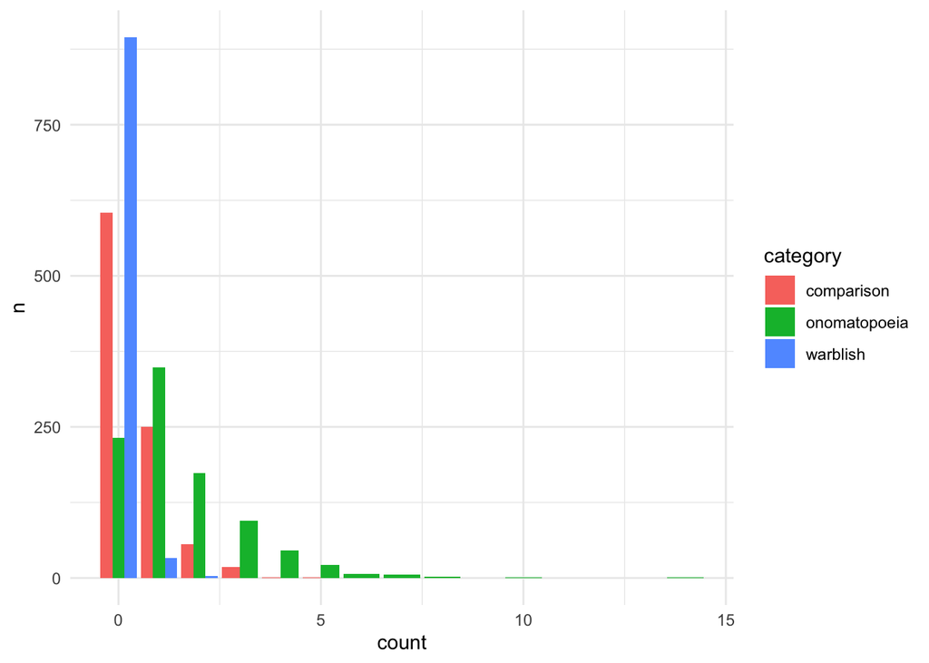

```r
category_counts |>
  ggplot(aes(x = count, y = n, fill = category)) +
  geom_col(position = 'dodge') +
  theme_minimal()
```

What percentage have comparison, onomatopoeia, warblish?

```r
birds <- mutate(birds,
                onom_01 = if_else(onom_count > 0, 1, 0),
                warblish_01 = if_else(warblish_count > 0, 1, 0),
                comparison_01 = if_else(comparison_count > 0, 1, 0))

# Onomatopoeias:

birds |>
  count(onom_01) |>
  mutate(p = n / sum(n))
```

```
## # A tibble: 2 × 3
##   onom_01     n     p
##     <dbl> <int> <dbl>
## 1       0   251 0.264
## 2       1   699 0.736
```

```r
# Comparisons:

birds |>
  count(comparison_01) |>
  mutate(p = n / sum(n))
```

```
## # A tibble: 2 × 3
##   comparison_01     n     p
##           <dbl> <int> <dbl>
## 1             0   605 0.637
## 2             1   345 0.363
```

```r
# Warblish:

birds |>
  count(warblish_01) |>
  mutate(p = n / sum(n))
```

```
## # A tibble: 2 × 3
##   warblish_01     n      p
##         <dbl> <int>  <dbl>
## 1           0   914 0.962
## 2           1    36 0.0379
```

Total number of each:

```r
birds |>
  summarize(onom_total = sum(onom_count),
            comparison_total = sum(comparison_count),
            warblish_total = sum(warblish_count))
```

```
## # A tibble: 1 × 3
##   onom_total comparison_total warblish_total
##        <dbl>            <dbl>          <dbl>
## 1       1382              444             39
```

Check how much these figures differ by different field guides, comparisons:

```r
birds |>
  count(fieldguide, comparison_01) |>
  group_by(fieldguide) |>
  mutate(p = n / sum(n)) |>
  filter(comparison_01 == 1) |>
  arrange(desc(p))
```

```
## # A tibble: 17 × 4
## # Groups:   fieldguide [17]
##    fieldguide                    comparison_01     n      p
##    <chr>                                 <dbl> <int>  <dbl>
##  1 sibley_birds                              1    80 0.678
##  2 allabout_birds                            1    46 0.517
##  3 bruun_hamlyn_guide                        1    30 0.462
##  4 national_geographic_america               1    44 0.386
##  5 peterson_chalif_mexico                    1    30 0.385
##  6 holden_cleeves_birds                      1    16 0.372
##  7 morcombe_australia                        1    40 0.354
##  8 tarboton_kruger_national_park             1     7 0.304
##  9 collins_gem_garden_birds                  1     6 0.3
## 10 rspb_pocket_birds_harrap                  1     8 0.286
## 11 collins_british_common                    1    10 0.238
## 12 collins_british_rare                      1     6 0.207
## 13 collins_gem_birds                         1     6 0.176
## 14 simpson_day_australian                    1     9 0.138
## 15 mackinnon_china                           1     3 0.125
## 16 felix_hisek_birds                         1     3 0.0833
## 17 national_trust_bird_spotter               1     1 0.0526
```

Check how much these figures differ by different field guides, onomatopoeias:

```r
birds |>
  count(fieldguide, onom_01) |>
  group_by(fieldguide) |>
  mutate(p = n / sum(n)) |>
  filter(onom_01 == 1) |>
  arrange(desc(p))
```

```
## # A tibble: 18 × 4
## # Groups:   fieldguide [18]
##    fieldguide                    onom_01     n     p
##    <chr>                           <dbl> <int> <dbl>
##  1 collins_british_rare                1    28 0.966
##  2 rspb_brereton                       1     9 0.9
##  3 national_trust_bird_spotter         1    17 0.895
##  4 felix_hisek_birds                   1    31 0.861
##  5 sibley_birds                        1   101 0.856
##  6 peterson_chalif_mexico              1    66 0.846
##  7 morcombe_australia                  1    95 0.841
##  8 holden_cleeves_birds                1    34 0.791
##  9 rspb_pocket_birds_harrap            1    22 0.786
## 10 collins_british_common              1    31 0.738
## 11 national_geographic_america         1    83 0.728
## 12 allabout_birds                      1    62 0.697
## 13 collins_gem_birds                   1    21 0.618
## 14 simpson_day_australian              1    38 0.585
## 15 bruun_hamlyn_guide                  1    35 0.538
## 16 tarboton_kruger_national_park       1    12 0.522
## 17 mackinnon_china                     1    10 0.417
## 18 collins_gem_garden_birds            1     4 0.2
```

# 9 Comparison to smell descriptions

Load iconicity ratings:

```r
icon <- read_csv('../data/iconicity_ratings_cleaned.csv')
```

Merge with bird data:

```r
birds_long <- left_join(birds_long,
                        select(icon, word, rating))
```

Load in Thomas Poulton’s smell descriptions:

```r
# Load:

smell <- read_csv('../data/poulton_coded_descriptions.csv')

# Unnest tokens:

smell_long <- smell |>
  unnest_tokens(word, DESCRIPTION)

# Merge with iconicity ratings:

smell_long <- left_join(smell_long,
                        select(icon, word, rating))
```

Put the two on top of each other:

```r
both <- bind_rows(select(birds_long, word, rating),
                  select(smell_long, word, rating))

# Add identifiers:

both$type <- c(rep('sound', nrow(birds_long)),
               rep('smell', nrow(smell_long)))

# Get rid of NAs:

both <- filter(both, !is.na(rating))
```

Make a plot of this:

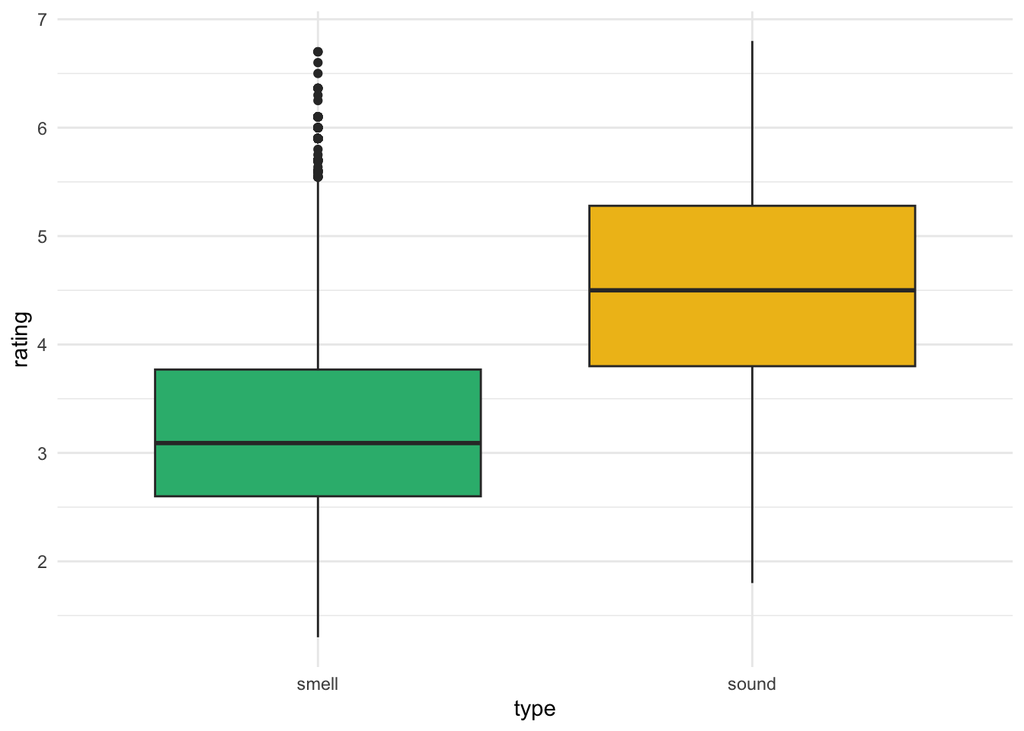

```r
# Make ggplot:

both |>
  ggplot(aes(x = type, y = rating, fill = type)) +
  geom_boxplot() +
  scale_fill_manual(values = c('#30b77d', '#efbe1b')) +
  theme_minimal() +
  theme(legend.position = 'none')
```

```r
# Save picture:

ggsave('../figures/smell_sound_iconicity_boxplot.pdf',
       width = 3.5, height = 4.5)
```

Make a density graph of this, first with smell only:

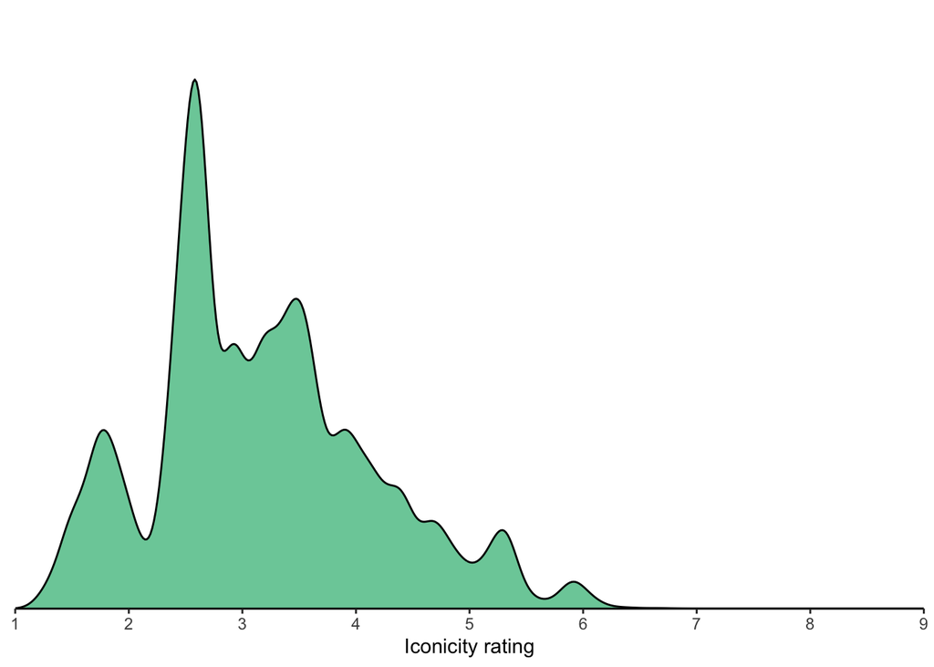

```r
# Make ggplot:

both |>
  filter(type == 'smell') |>
  ggplot(aes(x = rating, fill = type)) +
  geom_density(alpha = 0.7) +
  scale_fill_manual(values = '#30b77d') +
  # scale_fill_manual(values = c('#30b77d', '#efbe1b')) +
  scale_y_continuous(expand = c(0, 0),
                     limits = c(0, 0.8)) +
  scale_x_continuous(limits = c(1, 9),
                     expand = c(0, 0),
                     breaks = 1:9) +
  xlab("Iconicity rating") +
  ylab(NULL) +
  theme_classic() +
  theme(legend.position = 'none',
        axis.text.y = element_blank(),
        axis.ticks.y = element_blank(),
        axis.line.y = element_blank())
```

```r
# Save:

ggsave('../figures/smell_sound_iconicity_density_smell_only.pdf',
       width = 4, height = 3.1)
```

Now with both:

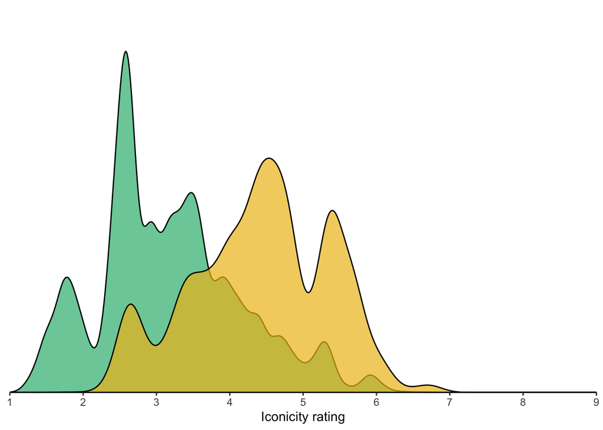

```r
# Make ggplot:

both |>
  ggplot(aes(x = rating, fill = type)) +
  geom_density(alpha = 0.7) +
  scale_fill_manual(values = c('#30b77d', '#efbe1b')) +
  scale_y_continuous(expand = c(0, 0),
                     limits = c(0, 0.8)) +
  scale_x_continuous(limits = c(1, 9),
                     expand = c(0, 0),
                     breaks = 1:9) +
  xlab("Iconicity rating") +
  ylab(NULL) +
  theme_classic() +
  theme(legend.position = 'none',
        axis.text.y = element_blank(),
        axis.ticks.y = element_blank(),
        axis.line.y = element_blank())
```

```r
# Save:

ggsave('../figures/smell_sound_iconicity_density.pdf',
       width = 4, height = 3.1)
```

Check effect size of this:

```r
cohen.d(rating ~ type, data = both)
```

```
##
## Cohen's d
##
## d estimate: -1.279155 (large)
## 95 percent confidence interval:
##     lower     upper
## -1.317499 -1.240811
```

## 9.1 Smell & comparisons

Also, check source based language:

```r
smell <- mutate(smell,
                has_source = if_else(SOURCE > 0, 'has source-based', 'no source-based'))

# Source-based language:

smell_comparison_count <- smell |>
  count(has_source) |>
  mutate(p = n / sum(n))

# Show:

smell_comparison_count
```

```
## # A tibble: 2 × 3
##   has_source           n     p
##   <chr>            <int> <dbl>
## 1 has source-based  1940 0.519
## 2 no source-based   1796 0.481
```

Make a plot of this versus our count:

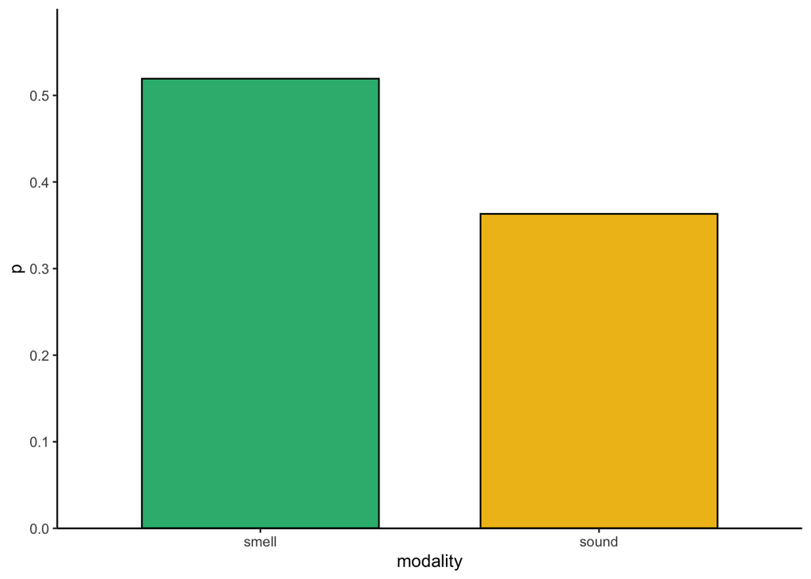

```r
# Make names the same:

smell_comparison_count <- smell_comparison_count |>
  rename(comparison_01 = has_source) |>
  mutate(comparison_01 = if_else(comparison_01 == 'has source-based',
                                 'comparison', 'no comparison'))

sound_comparison_count <- birds |>
  count(comparison_01) |>
  mutate(p = n / sum(n)) |>
  mutate(comparison_01 = if_else(comparison_01 == 0, 'no comparison',
                                 'comparison'))

# Put both together:

comparison_comparison <- bind_rows(smell_comparison_count,
                                   sound_comparison_count)
comparison_comparison$modality <- c('smell', 'smell',
                                    'sound', 'sound')

# Make bar plot out of this:

comparison_comparison |>
  filter(comparison_01 == 'comparison') |>
  ggplot(aes(x = modality, y = p, fill = modality)) +
  geom_col(width = 0.7, col = 'black') +
  scale_fill_manual(values = c('#30b77d', '#efbe1b')) +
  scale_y_continuous(expand = c(0, 0),
                     limits = c(0, 0.6)) +
  theme_classic() +
  theme(legend.position = 'none')
```

```r
ggsave('../figures/comparisons_sound_smell.pdf',
       width = 2.5, height = 3.8)
```

## 9.2 Smell & touch words

Check the smell descriptions for word frequencies and touch metaphors:

```r
# Get rid of stop words:

smell_long <- smell_long |> anti_join(stop_words)
# Tabulate most frequent words and skim for touch words:

smell_long |>
  count(word, sort = TRUE) |>
  print(n = 500)
```

```
## # A tibble: 1,502 × 2
##     word             n
##     <chr>        <int>
##   1 smells         743
##   2 smell          372
##   3 yeah           254
##   4 kinda          188
##   5 sweet          181
##   6 bit            139
##   7 strong         139
##   8 fresh          115
##   9 scent          102
##  10 sort            94
##  11 umm             76
##  12 nice            73
```

[output cut: 489 more lines]

Check these touch words:

```r
smell_touch_words <- c('abrasive', 'harder', 'duller',
                       'cutting', 'soft', 'hard',
                       'dried', 'wet', 'warm',
                       'sharp', 'wooden', 'texture',
                       'sharpish', 'sharpness', 'scratch',
                       'rough', 'cold')

# Regex vector:

smell_touch_words <- str_c(smell_touch_words, collapse = '|')

# Are these actually used to talk about the smell itself?

smell |>
  filter(str_detect(DESCRIPTION, smell_touch_words)) |>
  pull(DESCRIPTION)
```

```
##   [1] "I think my issue with smelling things is that, once I get fixated on what I think it is, it's hard to sort of veer away from it"
##   [2] "all these smells are very familiar, I just, it's really hard to"
##   [3] "they're getting harder, I'm convinced you're giving me the hard ones first"
##   [4] "you know when a fragrance goes straight up through your nose, and like hits ya?"
##   [5] "it's hard to describe scents"
##   [6] "it's a nice smell, I like it, yeah it's nice and minty but it's not hard mint"
##   [7] "it's hard to put your finger on though"
##   [8] "it's like dried cherries"
##   [9] "dried sweet cherries, like super sweet"
##  [10] "dried fruit"
##  [11] "I could very much feel like I'm walking through a bed of flowers"
##  [12] "so this is what I would call a duller scent"
##  [13] "they're the more, they're the stronger sort of smells that are coming through"
##  [14] "yeah, this is sort of walking through fresh grass on a spring morning, in fact the forest actually, there's that subtle sort of"
##  [15] "I'm waking through the forest, just after it's rained"
```

[output cut: 108 more lines]

I went through those descriptions and also checked oily (which refers to “from oil” and is used in a source-based way), and the ones that contain touch words like *soft*, *sharp*, or *abrasive* being used to describe smells are in this file:

```r
smell_mets <- read_lines('../data/tom_poulton_metaphorical_touch_smell_language.txt')
```

Check how many:

```r
# Create variable based on matching the texts above:

smell <- mutate(smell,
                has_haptic_metaphor = if_else(DESCRIPTION %in% smell_mets, 'has haptic metaphor', 'no haptic metaphor'))

# Check how frequent:

touch_count_smell <- smell |>
  count(has_haptic_metaphor) |>
  mutate(p = n / sum(n))

# Show:

touch_count_smell
```

```
## # A tibble: 2 × 3
##   has_haptic_metaphor     n      p
##   <chr>               <int>  <dbl>
## 1 has haptic metaphor    61 0.0163
## 2 no haptic metaphor   3675 0.984
```

```r
# Compare with the birds again:

touch_count_sound <- birds |>
  count(has_haptic_metaphor) |>
  filter(!is.na(has_haptic_metaphor)) |>
  mutate(p = n / sum(n))

# Show:

touch_count_sound
```

```
## # A tibble: 2 × 3
##   has_haptic_metaphor     n     p
##   <chr>               <int> <dbl>
## 1 has haptic metaphor   317 0.340
## 2 no haptic metaphor    614 0.660
```

Put them both together into the same tibble:

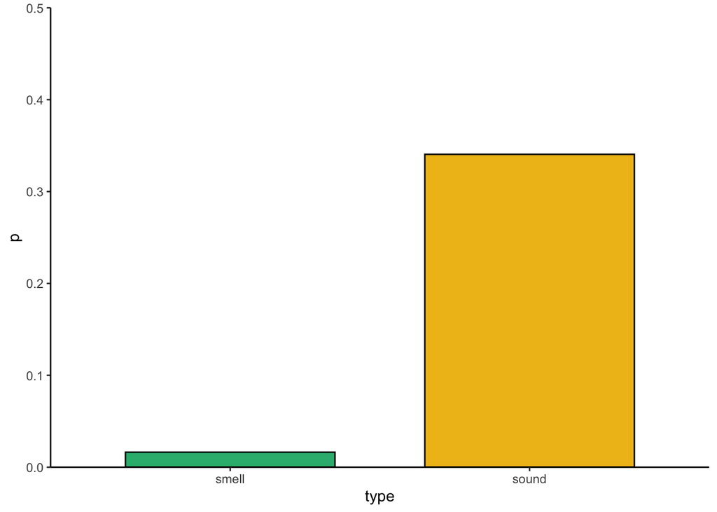

```r
touch_comparison <- bind_rows(touch_count_smell,
                              touch_count_sound)
touch_comparison$type <- c('smell', 'smell',
                           'sound', 'sound')

touch_comparison |>
  filter(has_haptic_metaphor == 'has haptic metaphor') |>
  ggplot(aes(x = type, y = p, fill = type)) +
  geom_col(width = 0.7, col = 'black') +
  scale_fill_manual(values = c('#30b77d', '#efbe1b')) +
  scale_y_continuous(expand = c(0, 0),
                     limits = c(0, 0.5)) +
  theme_classic() +
  theme(legend.position = 'none')
```

```r
ggsave('../figures/touch_metaphor_comparison_sound_smell.pdf',
       width = 2.5, height = 3.8)
```

## 9.3 Smell & sensory modality norms

Another approach is to use the Lynott & Connell (2009) norms:

```r
smell_long <- left_join(smell_long, lyn)
# Average tactile:

smell_means <- smell_long |>
  rename(unique_id = `DESCRIPTION NO.`) |>
  group_by(unique_id) |>
  summarize(hap_mean = mean(hap, na.rm = TRUE),
            vis_mean = mean(vis, na.rm = TRUE),
            aud_mean = mean(vis, na.rm = TRUE))

# Summarize:

smell_means |>
  summarize(hap_mean = mean(hap_mean, na.rm = TRUE),
            vis_mean = mean(vis_mean, na.rm = TRUE),
            aud_mean = mean(aud_mean, na.rm = TRUE))
```

```
## # A tibble: 1 × 3
##   hap_mean vis_mean aud_mean
##      <dbl>    <dbl>    <dbl>
## 1     1.90     3.35     3.35
```

```r
# For birds:

birds_long <- left_join(birds_long, lyn)
# Average tactile:

bird_means <- birds_long |>
  group_by(unique_id) |>
  summarize(hap_mean = mean(hap, na.rm = TRUE),
            vis_mean = mean(vis, na.rm = TRUE),
            aud_mean = mean(vis, na.rm = TRUE))

# Summarize:

bird_means |>
  summarize(hap_mean = mean(hap_mean, na.rm = TRUE),
            vis_mean = mean(vis_mean, na.rm = TRUE),
            aud_mean = mean(aud_mean, na.rm = TRUE))
```

```
## # A tibble: 1 × 3
##   hap_mean vis_mean aud_mean
##      <dbl>    <dbl>    <dbl>
## 1     2.20     3.11     3.11
```

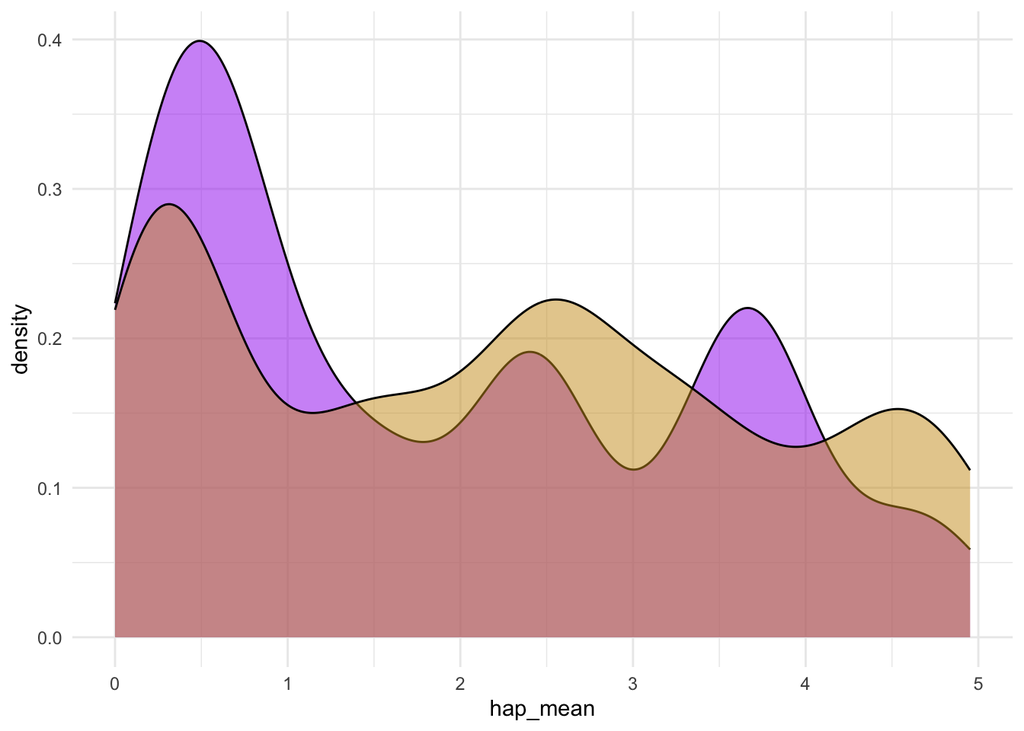

```r
# Reduce both to relevant columns:

bird_means_red <- bird_means |>
  select(unique_id, hap_mean)
smell_means_red <- smell_means |>
  select(unique_id, hap_mean) |>
  mutate(unique_id = as.character(unique_id))

# Bind together and create identifier variable:

both_means <- bind_rows(bird_means_red,
                        smell_means_red)
both_means$type <- c(rep('sound', nrow(bird_means_red)),
                     rep('smell', nrow(smell_means_red)))

# Make ggplot:

both_means |>
  ggplot(aes(x = hap_mean, fill = type)) +
  geom_density(alpha = 0.5) +
  scale_fill_manual(values = c('purple', 'goldenrod3')) +
  theme_minimal() +
  theme(legend.position = 'none')
```

```r
# Save picture:

ggsave('../figures/smell_sound_haptic_density.pdf',
       width = 3.5, height = 4.5)
```

Pretty much completely overlapping. Why?

```r
filter(smell_long, !is.na(hap))$word
```

```
##    [1] "hard"       "sweet"      "sweet"      "sweet"      "sweet"
##    [6] "sweet"      "fishy"      "fishy"      "sweet"      "hard"
##   [11] "alcoholic"  "blue"       "blue"       "hard"       "fresh"
##   [16] "fresh"      "fruity"     "fruity"     "salty"      "salty"
##   [21] "dry"        "floral"     "floral"     "floral"     "fruity"
##   [26] "fruity"     "fruity"     "fruity"     "straight"   "fresh"
##   [31] "fresh"      "sweet"      "flowery"    "hard"       "flowery"
##   [36] "flowery"    "flowery"    "flowery"    "floral"     "red"
##   [41] "pungent"    "black"      "black"      "black"      "black"
##   [46] "orange"     "fresh"      "fruity"     "fruity"     "floral"
##   [51] "floral"     "dirty"      "sweet"      "sweet"      "sweet"
##   [56] "sweet"      "floral"     "minty"      "minty"      "minty"
##   [61] "minty"      "hard"       "light"      "minty"      "light"
##   [66] "minty"      "fishy"      "salty"      "vinegary"   "white"
##   [71] "white"      "white"      "white"      "fresh"      "floral"
```

[output cut: 237 more lines]

With this matching approach, all the fruity and food-related terms, which have high haptic ratings, also are matched… but these aren’t really touch words. I think the other approach is more diagnostic of touch language in this case.

# 10 Which onomatopoeias most frequent?

```r
word_count |>
  filter(word_type == 'onomatopoeia') |>
  arrange(desc(n))
```

```
## # A tibble: 190 × 3
##    word           n word_type
##    <chr>      <int> <chr>
##  1 whistled      58 onomatopoeia
##  2 whistle       50 onomatopoeia
##  3 whistles      41 onomatopoeia
##  4 shrill        40 onomatopoeia
##  5 twittering    32 onomatopoeia
##  6 rattling      25 onomatopoeia
##  7 buzzy         24 onomatopoeia
##  8 rattle        24 onomatopoeia
##  9 ringing       23 onomatopoeia
## 10 chattering    22 onomatopoeia
## # ℹ 180 more rows
```